# Risk Factor Analysis

## Outcome Variable

**Outcome Variable:** pers_wast

## Predictor Variables

**Intervention Variable:** hhwealth_quart

**Adjustment Set:**

- arm
- sex
- W_mage
- meducyrs
- feducyrs
- W_gagebrth
- W_birthwt
- W_birthlen
- W_nchldlt5
- W_parity
- delta_W_mage
- delta_meducyrs
- delta_feducyrs
- delta_W_gagebrth
- delta_W_birthwt
- delta_W_birthlen
- delta_W_nchldlt5
- delta_W_parity

## Stratifying Variables

The analysis was stratified on these variable(s):

- agecat
- studyid
- country

## Data Summary

| agecat | studyid | country | hhwealth_quart | pers_wast | n_cell | n |
| --- | --- | --- | --- | --- | --- | --- |
| 0-24 months | CMC-V-BCS-2002 | INDIA | Wealth Q4 | 0 | 93 | 373 |
| 0-24 months | CMC-V-BCS-2002 | INDIA | Wealth Q4 | 1 | 3 | 373 |
| 0-24 months | CMC-V-BCS-2002 | INDIA | Wealth Q1 | 0 | 83 | 373 |
| 0-24 months | CMC-V-BCS-2002 | INDIA | Wealth Q1 | 1 | 8 | 373 |
| 0-24 months | CMC-V-BCS-2002 | INDIA | Wealth Q2 | 0 | 89 | 373 |
| 0-24 months | CMC-V-BCS-2002 | INDIA | Wealth Q2 | 1 | 6 | 373 |
| 0-24 months | CMC-V-BCS-2002 | INDIA | Wealth Q3 | 0 | 85 | 373 |
| 0-24 months | CMC-V-BCS-2002 | INDIA | Wealth Q3 | 1 | 6 | 373 |
| 0-24 months | COHORTS | GUATEMALA | Wealth Q4 | 0 | 375 | 1023 |
| 0-24 months | COHORTS | GUATEMALA | Wealth Q4 | 1 | 9 | 1023 |
| 0-24 months | COHORTS | GUATEMALA | Wealth Q1 | 0 | 199 | 1023 |
| 0-24 months | COHORTS | GUATEMALA | Wealth Q1 | 1 | 4 | 1023 |
| 0-24 months | COHORTS | GUATEMALA | Wealth Q2 | 0 | 197 | 1023 |
| 0-24 months | COHORTS | GUATEMALA | Wealth Q2 | 1 | 11 | 1023 |
| 0-24 months | COHORTS | GUATEMALA | Wealth Q3 | 0 | 217 | 1023 |
| 0-24 months | COHORTS | GUATEMALA | Wealth Q3 | 1 | 11 | 1023 |
| 0-24 months | COHORTS | PHILIPPINES | Wealth Q4 | 0 | 754 | 2811 |
| 0-24 months | COHORTS | PHILIPPINES | Wealth Q4 | 1 | 19 | 2811 |
| 0-24 months | COHORTS | PHILIPPINES | Wealth Q1 | 0 | 556 | 2811 |
| 0-24 months | COHORTS | PHILIPPINES | Wealth Q1 | 1 | 48 | 2811 |
| 0-24 months | COHORTS | PHILIPPINES | Wealth Q2 | 0 | 476 | 2811 |
| 0-24 months | COHORTS | PHILIPPINES | Wealth Q2 | 1 | 27 | 2811 |
| 0-24 months | COHORTS | PHILIPPINES | Wealth Q3 | 0 | 881 | 2811 |
| 0-24 months | COHORTS | PHILIPPINES | Wealth Q3 | 1 | 50 | 2811 |
| 0-24 months | CONTENT | PERU | Wealth Q4 | 0 | 52 | 215 |
| 0-24 months | CONTENT | PERU | Wealth Q4 | 1 | 0 | 215 |
| 0-24 months | CONTENT | PERU | Wealth Q1 | 0 | 59 | 215 |
| 0-24 months | CONTENT | PERU | Wealth Q1 | 1 | 0 | 215 |
| 0-24 months | CONTENT | PERU | Wealth Q2 | 0 | 52 | 215 |
| 0-24 months | CONTENT | PERU | Wealth Q2 | 1 | 0 | 215 |

[output cut: 378 more lines]

The following strata were considered:

- agecat: 0-24 months, studyid: CMC-V-BCS-2002, country: INDIA
- agecat: 0-24 months, studyid: COHORTS, country: GUATEMALA
- agecat: 0-24 months, studyid: COHORTS, country: PHILIPPINES
- agecat: 0-24 months, studyid: CONTENT, country: PERU
- agecat: 0-24 months, studyid: GMS-Nepal, country: NEPAL
- agecat: 0-24 months, studyid: IRC, country: INDIA
- agecat: 0-24 months, studyid: JiVitA-3, country: BANGLADESH
- agecat: 0-24 months, studyid: JiVitA-4, country: BANGLADESH
- agecat: 0-24 months, studyid: LCNI-5, country: MALAWI
- agecat: 0-24 months, studyid: MAL-ED, country: BANGLADESH
- agecat: 0-24 months, studyid: MAL-ED, country: BRAZIL
- agecat: 0-24 months, studyid: MAL-ED, country: INDIA
- agecat: 0-24 months, studyid: MAL-ED, country: NEPAL
- agecat: 0-24 months, studyid: MAL-ED, country: PERU
- agecat: 0-24 months, studyid: MAL-ED, country: SOUTH AFRICA
- agecat: 0-24 months, studyid: MAL-ED, country: TANZANIA, UNITED REPUBLIC OF
- agecat: 0-24 months, studyid: PROVIDE, country: BANGLADESH
- agecat: 0-24 months, studyid: TanzaniaChild2, country: TANZANIA, UNITED REPUBLIC OF
- agecat: 0-6 months, studyid: CMC-V-BCS-2002, country: INDIA
- agecat: 0-6 months, studyid: COHORTS, country: PHILIPPINES
- agecat: 0-6 months, studyid: CONTENT, country: PERU
- agecat: 0-6 months, studyid: GMS-Nepal, country: NEPAL
- agecat: 0-6 months, studyid: IRC, country: INDIA
- agecat: 0-6 months, studyid: JiVitA-3, country: BANGLADESH
- agecat: 0-6 months, studyid: MAL-ED, country: BANGLADESH
- agecat: 0-6 months, studyid: MAL-ED, country: BRAZIL
- agecat: 0-6 months, studyid: MAL-ED, country: INDIA
- agecat: 0-6 months, studyid: MAL-ED, country: NEPAL
- agecat: 0-6 months, studyid: MAL-ED, country: PERU
- agecat: 0-6 months, studyid: MAL-ED, country: SOUTH AFRICA
- agecat: 0-6 months, studyid: MAL-ED, country: TANZANIA, UNITED REPUBLIC OF
- agecat: 0-6 months, studyid: PROVIDE, country: BANGLADESH
- agecat: 0-6 months, studyid: TanzaniaChild2, country: TANZANIA, UNITED REPUBLIC OF
- agecat: 6-24 months, studyid: CMC-V-BCS-2002, country: INDIA
- agecat: 6-24 months, studyid: COHORTS, country: GUATEMALA
- agecat: 6-24 months, studyid: COHORTS, country: PHILIPPINES
- agecat: 6-24 months, studyid: CONTENT, country: PERU
- agecat: 6-24 months, studyid: GMS-Nepal, country: NEPAL
- agecat: 6-24 months, studyid: IRC, country: INDIA
- agecat: 6-24 months, studyid: JiVitA-3, country: BANGLADESH
- agecat: 6-24 months, studyid: JiVitA-4, country: BANGLADESH
- agecat: 6-24 months, studyid: LCNI-5, country: MALAWI
- agecat: 6-24 months, studyid: MAL-ED, country: BANGLADESH
- agecat: 6-24 months, studyid: MAL-ED, country: BRAZIL
- agecat: 6-24 months, studyid: MAL-ED, country: INDIA
- agecat: 6-24 months, studyid: MAL-ED, country: NEPAL
- agecat: 6-24 months, studyid: MAL-ED, country: PERU
- agecat: 6-24 months, studyid: MAL-ED, country: SOUTH AFRICA
- agecat: 6-24 months, studyid: MAL-ED, country: TANZANIA, UNITED REPUBLIC OF
- agecat: 6-24 months, studyid: PROVIDE, country: BANGLADESH
- agecat: 6-24 months, studyid: TanzaniaChild2, country: TANZANIA, UNITED REPUBLIC OF

### Dropped Strata

Some strata were dropped due to rare outcomes:

- agecat: 0-24 months, studyid: CMC-V-BCS-2002, country: INDIA
- agecat: 0-24 months, studyid: COHORTS, country: GUATEMALA
- agecat: 0-24 months, studyid: CONTENT, country: PERU
- agecat: 0-24 months, studyid: LCNI-5, country: MALAWI
- agecat: 0-24 months, studyid: MAL-ED, country: BANGLADESH
- agecat: 0-24 months, studyid: MAL-ED, country: BRAZIL
- agecat: 0-24 months, studyid: MAL-ED, country: INDIA
- agecat: 0-24 months, studyid: MAL-ED, country: NEPAL
- agecat: 0-24 months, studyid: MAL-ED, country: PERU
- agecat: 0-24 months, studyid: MAL-ED, country: SOUTH AFRICA
- agecat: 0-24 months, studyid: MAL-ED, country: TANZANIA, UNITED REPUBLIC OF
- agecat: 0-24 months, studyid: PROVIDE, country: BANGLADESH
- agecat: 0-6 months, studyid: CONTENT, country: PERU
- agecat: 0-6 months, studyid: JiVitA-3, country: BANGLADESH
- agecat: 0-6 months, studyid: MAL-ED, country: BANGLADESH
- agecat: 0-6 months, studyid: MAL-ED, country: BRAZIL
- agecat: 0-6 months, studyid: MAL-ED, country: INDIA
- agecat: 0-6 months, studyid: MAL-ED, country: NEPAL
- agecat: 0-6 months, studyid: MAL-ED, country: PERU
- agecat: 0-6 months, studyid: MAL-ED, country: SOUTH AFRICA
- agecat: 0-6 months, studyid: MAL-ED, country: TANZANIA, UNITED REPUBLIC OF
- agecat: 0-6 months, studyid: PROVIDE, country: BANGLADESH
- agecat: 6-24 months, studyid: CMC-V-BCS-2002, country: INDIA
- agecat: 6-24 months, studyid: COHORTS, country: GUATEMALA
- agecat: 6-24 months, studyid: CONTENT, country: PERU
- agecat: 6-24 months, studyid: LCNI-5, country: MALAWI
- agecat: 6-24 months, studyid: MAL-ED, country: BANGLADESH
- agecat: 6-24 months, studyid: MAL-ED, country: BRAZIL
- agecat: 6-24 months, studyid: MAL-ED, country: INDIA
- agecat: 6-24 months, studyid: MAL-ED, country: NEPAL
- agecat: 6-24 months, studyid: MAL-ED, country: PERU
- agecat: 6-24 months, studyid: MAL-ED, country: SOUTH AFRICA
- agecat: 6-24 months, studyid: MAL-ED, country: TANZANIA, UNITED REPUBLIC OF
- agecat: 6-24 months, studyid: PROVIDE, country: BANGLADESH

## Methods Detail

We’re interested in the causal parameters $E[Y_a]$ for all values of $a \in \mathcal{A}$. These parameters represent the mean outcome if, possibly contrary to fact, we intervened to set all units to have $A=a$. Under the randomization and positivity assumptions, these are identified by the statistical parameters $\psi_a=E_W[E_{Y|A,W}(Y|A=a,W)]$. In addition, we’re interested in the mean of $Y$, $E[Y]$ under no intervention (the observed mean). We will estimate these parameters by using SuperLearner to fit the relevant likelihood factors – $E_{Y|A,W}(Y|A=a,W)$ and $p(A=a|W)$, and then updating our likelihood fit using a joint TMLE.

For unadjusted analyses ($W=\{\}$), initial likelihoods were estimated using Lrnr_glm to estimate the simple $E(Y|A)$ and Lrnr_mean to estimate $p(A)$. For adjusted analyses, a small library containing Lrnr_glmnet, Lrnr_xgboost, and Lrnr_mean was used.

Having estimated these parameters, we will then use the delta method to estimate relative risks and attributable risks relative to a prespecified baseline level of $A$.

# Results Detail

## Results Plots

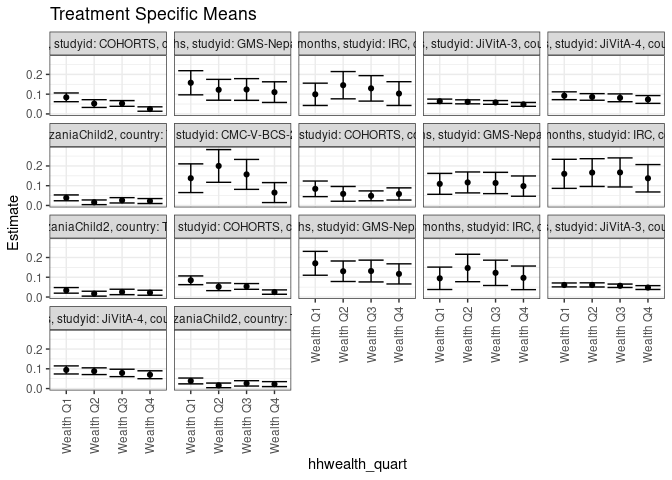

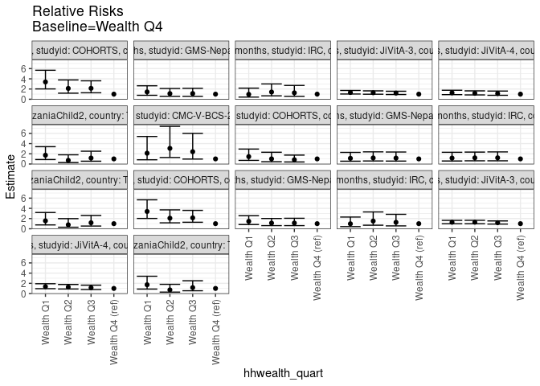

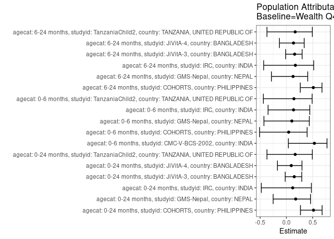

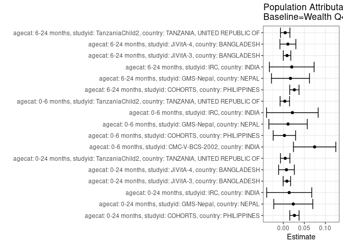

## Results Table

### Parameter: TSM

| agecat | studyid | country | intervention_level | baseline_level | estimate | ci_lower | ci_upper |
| --- | --- | --- | --- | --- | --- | --- | --- |
| 0-24 months | COHORTS | PHILIPPINES | Wealth Q4 | NA | 0.0247808 | 0.0137489 | 0.0358128 |
| 0-24 months | COHORTS | PHILIPPINES | Wealth Q1 | NA | 0.0839535 | 0.0618905 | 0.1060165 |
| 0-24 months | COHORTS | PHILIPPINES | Wealth Q2 | NA | 0.0524963 | 0.0329706 | 0.0720220 |
| 0-24 months | COHORTS | PHILIPPINES | Wealth Q3 | NA | 0.0530263 | 0.0385597 | 0.0674928 |
| 0-24 months | GMS-Nepal | NEPAL | Wealth Q4 | NA | 0.1102636 | 0.0579804 | 0.1625467 |
| 0-24 months | GMS-Nepal | NEPAL | Wealth Q1 | NA | 0.1576947 | 0.0965288 | 0.2188606 |
| 0-24 months | GMS-Nepal | NEPAL | Wealth Q2 | NA | 0.1222567 | 0.0695099 | 0.1750035 |
| 0-24 months | GMS-Nepal | NEPAL | Wealth Q3 | NA | 0.1236920 | 0.0688627 | 0.1785213 |
| 0-24 months | IRC | INDIA | Wealth Q4 | NA | 0.1030310 | 0.0428611 | 0.1632010 |
| 0-24 months | IRC | INDIA | Wealth Q1 | NA | 0.0992398 | 0.0428930 | 0.1555866 |
| 0-24 months | IRC | INDIA | Wealth Q2 | NA | 0.1454579 | 0.0764625 | 0.2144532 |
| 0-24 months | IRC | INDIA | Wealth Q3 | NA | 0.1294038 | 0.0649626 | 0.1938450 |
| 0-24 months | JiVitA-3 | BANGLADESH | Wealth Q4 | NA | 0.0483045 | 0.0385522 | 0.0580567 |
| 0-24 months | JiVitA-3 | BANGLADESH | Wealth Q1 | NA | 0.0641029 | 0.0531606 | 0.0750452 |
| 0-24 months | JiVitA-3 | BANGLADESH | Wealth Q2 | NA | 0.0612406 | 0.0511381 | 0.0713432 |
| 0-24 months | JiVitA-3 | BANGLADESH | Wealth Q3 | NA | 0.0580986 | 0.0486699 | 0.0675273 |
| 0-24 months | JiVitA-4 | BANGLADESH | Wealth Q4 | NA | 0.0732172 | 0.0534717 | 0.0929627 |
| 0-24 months | JiVitA-4 | BANGLADESH | Wealth Q1 | NA | 0.0919984 | 0.0721765 | 0.1118202 |
| 0-24 months | JiVitA-4 | BANGLADESH | Wealth Q2 | NA | 0.0861140 | 0.0694181 | 0.1028100 |
| 0-24 months | JiVitA-4 | BANGLADESH | Wealth Q3 | NA | 0.0814837 | 0.0617134 | 0.1012540 |
| 0-24 months | TanzaniaChild2 | TANZANIA, UNITED REPUBLIC OF | Wealth Q4 | NA | 0.0223881 | 0.0098607 | 0.0349154 |
| 0-24 months | TanzaniaChild2 | TANZANIA, UNITED REPUBLIC OF | Wealth Q1 | NA | 0.0385208 | 0.0237112 | 0.0533304 |
| 0-24 months | TanzaniaChild2 | TANZANIA, UNITED REPUBLIC OF | Wealth Q2 | NA | 0.0160183 | 0.0042447 | 0.0277919 |
| 0-24 months | TanzaniaChild2 | TANZANIA, UNITED REPUBLIC OF | Wealth Q3 | NA | 0.0261682 | 0.0126381 | 0.0396983 |
| 0-6 months | CMC-V-BCS-2002 | INDIA | Wealth Q4 | NA | 0.0652174 | 0.0146933 | 0.1157415 |
| 0-6 months | CMC-V-BCS-2002 | INDIA | Wealth Q1 | NA | 0.1379310 | 0.0653709 | 0.2104911 |
| 0-6 months | CMC-V-BCS-2002 | INDIA | Wealth Q2 | NA | 0.2000000 | 0.1172450 | 0.2827550 |
| 0-6 months | CMC-V-BCS-2002 | INDIA | Wealth Q3 | NA | 0.1573034 | 0.0815564 | 0.2330503 |
| 0-6 months | COHORTS | PHILIPPINES | Wealth Q4 | NA | 0.0582960 | 0.0275260 | 0.0890659 |
| 0-6 months | COHORTS | PHILIPPINES | Wealth Q1 | NA | 0.0842105 | 0.0447005 | 0.1237205 |
| 0-6 months | COHORTS | PHILIPPINES | Wealth Q2 | NA | 0.0588235 | 0.0215184 | 0.0961286 |
| 0-6 months | COHORTS | PHILIPPINES | Wealth Q3 | NA | 0.0487805 | 0.0238446 | 0.0737164 |
| 0-6 months | GMS-Nepal | NEPAL | Wealth Q4 | NA | 0.0980553 | 0.0467098 | 0.1494008 |
| 0-6 months | GMS-Nepal | NEPAL | Wealth Q1 | NA | 0.1093410 | 0.0564375 | 0.1622445 |
| 0-6 months | GMS-Nepal | NEPAL | Wealth Q2 | NA | 0.1165794 | 0.0636056 | 0.1695531 |
| 0-6 months | GMS-Nepal | NEPAL | Wealth Q3 | NA | 0.1137525 | 0.0598291 | 0.1676759 |
| 0-6 months | IRC | INDIA | Wealth Q4 | NA | 0.1376052 | 0.0683095 | 0.2069009 |
| 0-6 months | IRC | INDIA | Wealth Q1 | NA | 0.1601418 | 0.0865743 | 0.2337092 |
| 0-6 months | IRC | INDIA | Wealth Q2 | NA | 0.1663634 | 0.0961431 | 0.2365836 |
| 0-6 months | IRC | INDIA | Wealth Q3 | NA | 0.1672298 | 0.0937417 | 0.2407180 |
| 0-6 months | TanzaniaChild2 | TANZANIA, UNITED REPUBLIC OF | Wealth Q4 | NA | 0.0216963 | 0.0090116 | 0.0343809 |
| 0-6 months | TanzaniaChild2 | TANZANIA, UNITED REPUBLIC OF | Wealth Q1 | NA | 0.0337079 | 0.0195326 | 0.0478831 |
| 0-6 months | TanzaniaChild2 | TANZANIA, UNITED REPUBLIC OF | Wealth Q2 | NA | 0.0168675 | 0.0044749 | 0.0292600 |
| 0-6 months | TanzaniaChild2 | TANZANIA, UNITED REPUBLIC OF | Wealth Q3 | NA | 0.0255906 | 0.0118554 | 0.0393257 |
| 6-24 months | COHORTS | PHILIPPINES | Wealth Q4 | NA | 0.0249417 | 0.0138847 | 0.0359987 |
| 6-24 months | COHORTS | PHILIPPINES | Wealth Q1 | NA | 0.0845860 | 0.0624821 | 0.1066899 |
| 6-24 months | COHORTS | PHILIPPINES | Wealth Q2 | NA | 0.0517135 | 0.0323730 | 0.0710541 |
| 6-24 months | COHORTS | PHILIPPINES | Wealth Q3 | NA | 0.0534570 | 0.0389568 | 0.0679572 |
| 6-24 months | GMS-Nepal | NEPAL | Wealth Q4 | NA | 0.1169648 | 0.0659581 | 0.1679714 |
| 6-24 months | GMS-Nepal | NEPAL | Wealth Q1 | NA | 0.1706091 | 0.1102091 | 0.2310092 |
| 6-24 months | GMS-Nepal | NEPAL | Wealth Q2 | NA | 0.1303577 | 0.0784616 | 0.1822537 |
| 6-24 months | GMS-Nepal | NEPAL | Wealth Q3 | NA | 0.1314320 | 0.0762840 | 0.1865800 |
| 6-24 months | IRC | INDIA | Wealth Q4 | NA | 0.0970433 | 0.0373347 | 0.1567520 |
| 6-24 months | IRC | INDIA | Wealth Q1 | NA | 0.0946042 | 0.0379316 | 0.1512769 |
| 6-24 months | IRC | INDIA | Wealth Q2 | NA | 0.1469150 | 0.0775007 | 0.2163293 |
| 6-24 months | IRC | INDIA | Wealth Q3 | NA | 0.1224170 | 0.0583195 | 0.1865145 |
| 6-24 months | JiVitA-3 | BANGLADESH | Wealth Q4 | NA | 0.0478711 | 0.0381881 | 0.0575542 |
| 6-24 months | JiVitA-3 | BANGLADESH | Wealth Q1 | NA | 0.0610275 | 0.0510871 | 0.0709679 |
| 6-24 months | JiVitA-3 | BANGLADESH | Wealth Q2 | NA | 0.0611972 | 0.0506738 | 0.0717206 |
| 6-24 months | JiVitA-3 | BANGLADESH | Wealth Q3 | NA | 0.0569089 | 0.0482896 | 0.0655283 |
| 6-24 months | JiVitA-4 | BANGLADESH | Wealth Q4 | NA | 0.0697939 | 0.0497820 | 0.0898058 |
| 6-24 months | JiVitA-4 | BANGLADESH | Wealth Q1 | NA | 0.0942892 | 0.0738555 | 0.1147228 |
| 6-24 months | JiVitA-4 | BANGLADESH | Wealth Q2 | NA | 0.0878193 | 0.0707573 | 0.1048813 |
| 6-24 months | JiVitA-4 | BANGLADESH | Wealth Q3 | NA | 0.0790540 | 0.0602839 | 0.0978242 |
| 6-24 months | TanzaniaChild2 | TANZANIA, UNITED REPUBLIC OF | Wealth Q4 | NA | 0.0223881 | 0.0098607 | 0.0349154 |
| 6-24 months | TanzaniaChild2 | TANZANIA, UNITED REPUBLIC OF | Wealth Q1 | NA | 0.0385208 | 0.0237112 | 0.0533304 |
| 6-24 months | TanzaniaChild2 | TANZANIA, UNITED REPUBLIC OF | Wealth Q2 | NA | 0.0160183 | 0.0042447 | 0.0277919 |
| 6-24 months | TanzaniaChild2 | TANZANIA, UNITED REPUBLIC OF | Wealth Q3 | NA | 0.0261682 | 0.0126381 | 0.0396983 |

### Parameter: E(Y)

| agecat | studyid | country | intervention_level | baseline_level | estimate | ci_lower | ci_upper |
| --- | --- | --- | --- | --- | --- | --- | --- |
| 0-24 months | COHORTS | PHILIPPINES | NA | NA | 0.0512273 | 0.0430760 | 0.0593786 |
| 0-24 months | GMS-Nepal | NEPAL | NA | NA | 0.1340034 | 0.1066544 | 0.1613523 |
| 0-24 months | IRC | INDIA | NA | NA | 0.1170732 | 0.0859146 | 0.1482317 |
| 0-24 months | JiVitA-3 | BANGLADESH | NA | NA | 0.0567865 | 0.0526703 | 0.0609027 |
| 0-24 months | JiVitA-4 | BANGLADESH | NA | NA | 0.0806971 | 0.0720842 | 0.0893100 |
| 0-24 months | TanzaniaChild2 | TANZANIA, UNITED REPUBLIC OF | NA | NA | 0.0268892 | 0.0200612 | 0.0337172 |
| 0-6 months | CMC-V-BCS-2002 | INDIA | NA | NA | 0.1396648 | 0.1037072 | 0.1756225 |
| 0-6 months | COHORTS | PHILIPPINES | NA | NA | 0.0609613 | 0.0448957 | 0.0770269 |
| 0-6 months | GMS-Nepal | NEPAL | NA | NA | 0.1093474 | 0.0836377 | 0.1350572 |
| 0-6 months | IRC | INDIA | NA | NA | 0.1592040 | 0.1233945 | 0.1950135 |
| 0-6 months | TanzaniaChild2 | TANZANIA, UNITED REPUBLIC OF | NA | NA | 0.0253288 | 0.0185306 | 0.0321270 |
| 6-24 months | COHORTS | PHILIPPINES | NA | NA | 0.0512273 | 0.0430760 | 0.0593786 |
| 6-24 months | GMS-Nepal | NEPAL | NA | NA | 0.1340034 | 0.1066544 | 0.1613523 |
| 6-24 months | IRC | INDIA | NA | NA | 0.1170732 | 0.0859146 | 0.1482317 |
| 6-24 months | JiVitA-3 | BANGLADESH | NA | NA | 0.0567865 | 0.0526703 | 0.0609027 |
| 6-24 months | JiVitA-4 | BANGLADESH | NA | NA | 0.0806971 | 0.0720842 | 0.0893100 |
| 6-24 months | TanzaniaChild2 | TANZANIA, UNITED REPUBLIC OF | NA | NA | 0.0268892 | 0.0200612 | 0.0337172 |

### Parameter: RR

| agecat | studyid | country | intervention_level | baseline_level | estimate | ci_lower | ci_upper |
| --- | --- | --- | --- | --- | --- | --- | --- |
| 0-24 months | COHORTS | PHILIPPINES | Wealth Q4 | Wealth Q4 | 1.0000000 | 1.0000000 | 1.000000 |
| 0-24 months | COHORTS | PHILIPPINES | Wealth Q1 | Wealth Q4 | 3.3878399 | 2.0201766 | 5.681414 |
| 0-24 months | COHORTS | PHILIPPINES | Wealth Q2 | Wealth Q4 | 2.1184242 | 1.1860297 | 3.783819 |
| 0-24 months | COHORTS | PHILIPPINES | Wealth Q3 | Wealth Q4 | 2.1398095 | 1.2693536 | 3.607178 |
| 0-24 months | GMS-Nepal | NEPAL | Wealth Q4 | Wealth Q4 | 1.0000000 | 1.0000000 | 1.000000 |
| 0-24 months | GMS-Nepal | NEPAL | Wealth Q1 | Wealth Q4 | 1.4301614 | 0.7757989 | 2.636459 |
| 0-24 months | GMS-Nepal | NEPAL | Wealth Q2 | Wealth Q4 | 1.1087677 | 0.5837754 | 2.105888 |
| 0-24 months | GMS-Nepal | NEPAL | Wealth Q3 | Wealth Q4 | 1.1217848 | 0.5860095 | 2.147407 |
| 0-24 months | IRC | INDIA | Wealth Q4 | Wealth Q4 | 1.0000000 | 1.0000000 | 1.000000 |
| 0-24 months | IRC | INDIA | Wealth Q1 | Wealth Q4 | 0.9632030 | 0.4265404 | 2.175081 |
| 0-24 months | IRC | INDIA | Wealth Q2 | Wealth Q4 | 1.4117869 | 0.6642431 | 3.000622 |
| 0-24 months | IRC | INDIA | Wealth Q3 | Wealth Q4 | 1.2559691 | 0.5825893 | 2.707668 |
| 0-24 months | JiVitA-3 | BANGLADESH | Wealth Q4 | Wealth Q4 | 1.0000000 | 1.0000000 | 1.000000 |
| 0-24 months | JiVitA-3 | BANGLADESH | Wealth Q1 | Wealth Q4 | 1.3270585 | 1.0238130 | 1.720123 |
| 0-24 months | JiVitA-3 | BANGLADESH | Wealth Q2 | Wealth Q4 | 1.2678044 | 0.9813647 | 1.637850 |
| 0-24 months | JiVitA-3 | BANGLADESH | Wealth Q3 | Wealth Q4 | 1.2027587 | 0.9238988 | 1.565787 |
| 0-24 months | JiVitA-4 | BANGLADESH | Wealth Q4 | Wealth Q4 | 1.0000000 | 1.0000000 | 1.000000 |
| 0-24 months | JiVitA-4 | BANGLADESH | Wealth Q1 | Wealth Q4 | 1.2565132 | 0.8968161 | 1.760478 |
| 0-24 months | JiVitA-4 | BANGLADESH | Wealth Q2 | Wealth Q4 | 1.1761452 | 0.8435976 | 1.639784 |
| 0-24 months | JiVitA-4 | BANGLADESH | Wealth Q3 | Wealth Q4 | 1.1129038 | 0.7730273 | 1.602214 |
| 0-24 months | TanzaniaChild2 | TANZANIA, UNITED REPUBLIC OF | Wealth Q4 | Wealth Q4 | 1.0000000 | 1.0000000 | 1.000000 |
| 0-24 months | TanzaniaChild2 | TANZANIA, UNITED REPUBLIC OF | Wealth Q1 | Wealth Q4 | 1.7205958 | 0.8726409 | 3.392518 |
| 0-24 months | TanzaniaChild2 | TANZANIA, UNITED REPUBLIC OF | Wealth Q2 | Wealth Q4 | 0.7154844 | 0.2840630 | 1.802128 |
| 0-24 months | TanzaniaChild2 | TANZANIA, UNITED REPUBLIC OF | Wealth Q3 | Wealth Q4 | 1.1688474 | 0.5456139 | 2.503976 |
| 0-6 months | CMC-V-BCS-2002 | INDIA | Wealth Q4 | Wealth Q4 | 1.0000000 | 1.0000000 | 1.000000 |
| 0-6 months | CMC-V-BCS-2002 | INDIA | Wealth Q1 | Wealth Q4 | 2.1149425 | 0.8291086 | 5.394929 |
| 0-6 months | CMC-V-BCS-2002 | INDIA | Wealth Q2 | Wealth Q4 | 3.0666667 | 1.2741917 | 7.380714 |
| 0-6 months | CMC-V-BCS-2002 | INDIA | Wealth Q3 | Wealth Q4 | 2.4119850 | 0.9687855 | 6.005119 |
| 0-6 months | COHORTS | PHILIPPINES | Wealth Q4 | Wealth Q4 | 1.0000000 | 1.0000000 | 1.000000 |
| 0-6 months | COHORTS | PHILIPPINES | Wealth Q1 | Wealth Q4 | 1.4445344 | 0.7128959 | 2.927047 |
| 0-6 months | COHORTS | PHILIPPINES | Wealth Q2 | Wealth Q4 | 1.0090498 | 0.4421567 | 2.302761 |
| 0-6 months | COHORTS | PHILIPPINES | Wealth Q3 | Wealth Q4 | 0.8367730 | 0.4013236 | 1.744699 |
| 0-6 months | GMS-Nepal | NEPAL | Wealth Q4 | Wealth Q4 | 1.0000000 | 1.0000000 | 1.000000 |
| 0-6 months | GMS-Nepal | NEPAL | Wealth Q1 | Wealth Q4 | 1.1150948 | 0.5464356 | 2.275540 |
| 0-6 months | GMS-Nepal | NEPAL | Wealth Q2 | Wealth Q4 | 1.1889146 | 0.5944215 | 2.377972 |
| 0-6 months | GMS-Nepal | NEPAL | Wealth Q3 | Wealth Q4 | 1.1600853 | 0.5725464 | 2.350548 |
| 0-6 months | IRC | INDIA | Wealth Q4 | Wealth Q4 | 1.0000000 | 1.0000000 | 1.000000 |
| 0-6 months | IRC | INDIA | Wealth Q1 | Wealth Q4 | 1.1637767 | 0.5892345 | 2.298535 |
| 0-6 months | IRC | INDIA | Wealth Q2 | Wealth Q4 | 1.2089903 | 0.6266682 | 2.332427 |
| 0-6 months | IRC | INDIA | Wealth Q3 | Wealth Q4 | 1.2152867 | 0.6231727 | 2.370004 |
| 0-6 months | TanzaniaChild2 | TANZANIA, UNITED REPUBLIC OF | Wealth Q4 | Wealth Q4 | 1.0000000 | 1.0000000 | 1.000000 |
| 0-6 months | TanzaniaChild2 | TANZANIA, UNITED REPUBLIC OF | Wealth Q1 | Wealth Q4 | 1.5536261 | 0.7560946 | 3.192397 |
| 0-6 months | TanzaniaChild2 | TANZANIA, UNITED REPUBLIC OF | Wealth Q2 | Wealth Q4 | 0.7774370 | 0.3040121 | 1.988106 |
| 0-6 months | TanzaniaChild2 | TANZANIA, UNITED REPUBLIC OF | Wealth Q3 | Wealth Q4 | 1.1794918 | 0.5333532 | 2.608404 |
| 6-24 months | COHORTS | PHILIPPINES | Wealth Q4 | Wealth Q4 | 1.0000000 | 1.0000000 | 1.000000 |
| 6-24 months | COHORTS | PHILIPPINES | Wealth Q1 | Wealth Q4 | 3.3913463 | 2.0271063 | 5.673718 |
| 6-24 months | COHORTS | PHILIPPINES | Wealth Q2 | Wealth Q4 | 2.0733754 | 1.1608316 | 3.703281 |
| 6-24 months | COHORTS | PHILIPPINES | Wealth Q3 | Wealth Q4 | 2.1432773 | 1.2745099 | 3.604238 |
| 6-24 months | GMS-Nepal | NEPAL | Wealth Q4 | Wealth Q4 | 1.0000000 | 1.0000000 | 1.000000 |
| 6-24 months | GMS-Nepal | NEPAL | Wealth Q1 | Wealth Q4 | 1.4586372 | 0.8324832 | 2.555754 |
| 6-24 months | GMS-Nepal | NEPAL | Wealth Q2 | Wealth Q4 | 1.1145037 | 0.6172295 | 2.012409 |
| 6-24 months | GMS-Nepal | NEPAL | Wealth Q3 | Wealth Q4 | 1.1236888 | 0.6135289 | 2.058056 |
| 6-24 months | IRC | INDIA | Wealth Q4 | Wealth Q4 | 1.0000000 | 1.0000000 | 1.000000 |
| 6-24 months | IRC | INDIA | Wealth Q1 | Wealth Q4 | 0.9748660 | 0.4134573 | 2.298577 |
| 6-24 months | IRC | INDIA | Wealth Q2 | Wealth Q4 | 1.5139112 | 0.6956619 | 3.294599 |
| 6-24 months | IRC | INDIA | Wealth Q3 | Wealth Q4 | 1.2614675 | 0.5617364 | 2.832823 |
| 6-24 months | JiVitA-3 | BANGLADESH | Wealth Q4 | Wealth Q4 | 1.0000000 | 1.0000000 | 1.000000 |
| 6-24 months | JiVitA-3 | BANGLADESH | Wealth Q1 | Wealth Q4 | 1.2748285 | 0.9865514 | 1.647342 |
| 6-24 months | JiVitA-3 | BANGLADESH | Wealth Q2 | Wealth Q4 | 1.2783741 | 0.9861041 | 1.657269 |
| 6-24 months | JiVitA-3 | BANGLADESH | Wealth Q3 | Wealth Q4 | 1.1887939 | 0.9194178 | 1.537093 |
| 6-24 months | JiVitA-4 | BANGLADESH | Wealth Q4 | Wealth Q4 | 1.0000000 | 1.0000000 | 1.000000 |
| 6-24 months | JiVitA-4 | BANGLADESH | Wealth Q1 | Wealth Q4 | 1.3509656 | 0.9515152 | 1.918107 |
| 6-24 months | JiVitA-4 | BANGLADESH | Wealth Q2 | Wealth Q4 | 1.2582664 | 0.8896178 | 1.779679 |
| 6-24 months | JiVitA-4 | BANGLADESH | Wealth Q3 | Wealth Q4 | 1.1326780 | 0.7816106 | 1.641430 |
| 6-24 months | TanzaniaChild2 | TANZANIA, UNITED REPUBLIC OF | Wealth Q4 | Wealth Q4 | 1.0000000 | 1.0000000 | 1.000000 |
| 6-24 months | TanzaniaChild2 | TANZANIA, UNITED REPUBLIC OF | Wealth Q1 | Wealth Q4 | 1.7205958 | 0.8726409 | 3.392518 |
| 6-24 months | TanzaniaChild2 | TANZANIA, UNITED REPUBLIC OF | Wealth Q2 | Wealth Q4 | 0.7154844 | 0.2840630 | 1.802128 |
| 6-24 months | TanzaniaChild2 | TANZANIA, UNITED REPUBLIC OF | Wealth Q3 | Wealth Q4 | 1.1688474 | 0.5456139 | 2.503976 |

### Parameter: PAR

| agecat | studyid | country | intervention_level | baseline_level | estimate | ci_lower | ci_upper |
| --- | --- | --- | --- | --- | --- | --- | --- |
| 0-24 months | COHORTS | PHILIPPINES | Wealth Q4 | NA | 0.0264465 | 0.0154066 | 0.0374864 |
| 0-24 months | GMS-Nepal | NEPAL | Wealth Q4 | NA | 0.0237398 | -0.0226177 | 0.0700973 |
| 0-24 months | IRC | INDIA | Wealth Q4 | NA | 0.0140421 | -0.0394970 | 0.0675813 |
| 0-24 months | JiVitA-3 | BANGLADESH | Wealth Q4 | NA | 0.0084820 | -0.0004440 | 0.0174081 |
| 0-24 months | JiVitA-4 | BANGLADESH | Wealth Q4 | NA | 0.0074799 | -0.0112359 | 0.0261957 |
| 0-24 months | TanzaniaChild2 | TANZANIA, UNITED REPUBLIC OF | Wealth Q4 | NA | 0.0045011 | -0.0067043 | 0.0157066 |
| 0-6 months | CMC-V-BCS-2002 | INDIA | Wealth Q4 | NA | 0.0744474 | 0.0241121 | 0.1247827 |
| 0-6 months | COHORTS | PHILIPPINES | Wealth Q4 | NA | 0.0026653 | -0.0239778 | 0.0293084 |
| 0-6 months | GMS-Nepal | NEPAL | Wealth Q4 | NA | 0.0112921 | -0.0343539 | 0.0569381 |
| 0-6 months | IRC | INDIA | Wealth Q4 | NA | 0.0215987 | -0.0396955 | 0.0828930 |
| 0-6 months | TanzaniaChild2 | TANZANIA, UNITED REPUBLIC OF | Wealth Q4 | NA | 0.0036325 | -0.0076655 | 0.0149306 |
| 6-24 months | COHORTS | PHILIPPINES | Wealth Q4 | NA | 0.0262856 | 0.0152276 | 0.0373436 |
| 6-24 months | GMS-Nepal | NEPAL | Wealth Q4 | NA | 0.0170386 | -0.0282357 | 0.0623128 |
| 6-24 months | IRC | INDIA | Wealth Q4 | NA | 0.0200298 | -0.0331798 | 0.0732395 |
| 6-24 months | JiVitA-3 | BANGLADESH | Wealth Q4 | NA | 0.0089154 | 0.0000416 | 0.0177892 |
| 6-24 months | JiVitA-4 | BANGLADESH | Wealth Q4 | NA | 0.0109032 | -0.0079732 | 0.0297795 |
| 6-24 months | TanzaniaChild2 | TANZANIA, UNITED REPUBLIC OF | Wealth Q4 | NA | 0.0045011 | -0.0067043 | 0.0157066 |

### Parameter: PAF

| agecat | studyid | country | intervention_level | baseline_level | estimate | ci_lower | ci_upper |
| --- | --- | --- | --- | --- | --- | --- | --- |
| 0-24 months | COHORTS | PHILIPPINES | Wealth Q4 | NA | 0.5162575 | 0.2682485 | 0.6802100 |
| 0-24 months | GMS-Nepal | NEPAL | Wealth Q4 | NA | 0.1771581 | -0.2521934 | 0.4592938 |
| 0-24 months | IRC | INDIA | Wealth Q4 | NA | 0.1199434 | -0.4781320 | 0.4760280 |
| 0-24 months | JiVitA-3 | BANGLADESH | Wealth Q4 | NA | 0.1493672 | -0.0234602 | 0.2930099 |
| 0-24 months | JiVitA-4 | BANGLADESH | Wealth Q4 | NA | 0.0926913 | -0.1704741 | 0.2966874 |
| 0-24 months | TanzaniaChild2 | TANZANIA, UNITED REPUBLIC OF | Wealth Q4 | NA | 0.1673958 | -0.3700147 | 0.4939983 |
| 0-6 months | CMC-V-BCS-2002 | INDIA | Wealth Q4 | NA | 0.5330435 | 0.0379996 | 0.7733386 |
| 0-6 months | COHORTS | PHILIPPINES | Wealth Q4 | NA | 0.0437220 | -0.5101151 | 0.3944385 |
| 0-6 months | GMS-Nepal | NEPAL | Wealth Q4 | NA | 0.1032684 | -0.4276837 | 0.4367607 |
| 0-6 months | IRC | INDIA | Wealth Q4 | NA | 0.1356671 | -0.3486818 | 0.4460730 |
| 0-6 months | TanzaniaChild2 | TANZANIA, UNITED REPUBLIC OF | Wealth Q4 | NA | 0.1434153 | -0.4391887 | 0.4901729 |
| 6-24 months | COHORTS | PHILIPPINES | Wealth Q4 | NA | 0.5131171 | 0.2647837 | 0.6775712 |
| 6-24 months | GMS-Nepal | NEPAL | Wealth Q4 | NA | 0.1271505 | -0.2838587 | 0.4065809 |
| 6-24 months | IRC | INDIA | Wealth Q4 | NA | 0.1710882 | -0.4326000 | 0.5203861 |
| 6-24 months | JiVitA-3 | BANGLADESH | Wealth Q4 | NA | 0.1569982 | -0.0148266 | 0.2997305 |
| 6-24 months | JiVitA-4 | BANGLADESH | Wealth Q4 | NA | 0.1351126 | -0.1323272 | 0.3393868 |
| 6-24 months | TanzaniaChild2 | TANZANIA, UNITED REPUBLIC OF | Wealth Q4 | NA | 0.1673958 | -0.3700147 | 0.4939983 |